# Prediction Assignment Machine Learning

Ashish

21 March 2018

## Executive Summary

#### One thing that people regularly do is quantify how much of a particular activity they do, but they rarely quantify how well they do it. In this project, the goal is to analyze data from accelerometers on the belt, forearm, arm, and dumbell of six participants. They were asked to perform barbell lifts correctly and incorrectly in five different ways. For more information see the “Weight Lifting Exercises Dataset” in the following location:

##### http://groupware.les.inf.puc-rio.br/har

##### Specifically, the goal of this machine learning exercise is to predict the manner in which the participants did the exercise-that is, to predict the “classe” variable found in the training set. The prediction model will then be used to predict twenty different test cases, as provided in the testing dataset.

##### Data Processing and Analysis

##### The training and testing datasets used in the analysis may be found as follows:

##### Training dataset:

##### https://d396qusza40orc.cloudfront.net/predmachlearn/pml-training.csv

##### Testing dataset:

##### https://d396qusza40orc.cloudfront.net/predmachlearn/pml-testing.csv

##### We begin by loading the required libraries and reading in the training and testing datasets, assigning missing values to entries that are currently ‘NA’ or blank:

## Goal of assignment

#### project is to predict the manner in which they did the exercise. This is the “classe” variable in the training set. You may use any of the other variables to predict with. You should create a report describing how you built your model, how you used cross validation, what you think the expected out of sample error is, and why you made the choices you did. You will also use your prediction model to predict 20 different test cases.

```r
# Loading the libraries
library(caret)
```

```r
library(rpart)
library(rpart.plot)
library(randomForest)
```

## DATA ACQUISITION

##### Loading the dataset from the URL. After the training datased should be divided by two parts: training and testing sets. 80% of the dataset is used for modeling, 20% of the dataset is used for the quiz result.

```r
data <- read.csv("pml-training.csv", na.strings=c("NA","#DIV/0!",""))
data_test <- read.csv("pml-testing.csv", na.strings=c("NA","#DIV/0!",""))



train <- createDataPartition(y = data$classe, p=.80, list = F)
training <- data[train,]
testing <- data[-train,]

# Cleaning the dataset and correction analysis

col_names <- grep("name|timestamp|window|X", colnames(training), value=F)
training_columns <- training[,-col_names]
#select variables with high (over 95%) missing data --> exclude them from the analysis
training_columns[training_columns==""] <- NA
NArate <- apply(training_columns, 2, function(x) sum(is.na(x)))/nrow(training_columns)
training_columns <- training_columns[!(NArate>0.95)]
summary(training_columns)
```

```
##    roll_belt        pitch_belt          yaw_belt      total_accel_belt
##  Min.   :-28.80   Min.   :-55.8000   Min.   :-180.0   Min.   : 0.00
##  1st Qu.:  1.09   1st Qu.:  1.7700   1st Qu.: -88.3   1st Qu.: 3.00
##  Median :113.00   Median :  5.2800   Median : -13.0   Median :17.00
##  Mean   : 64.40   Mean   :  0.2728   Mean   : -11.2   Mean   :11.31
##  3rd Qu.:123.00   3rd Qu.: 14.9000   3rd Qu.:  12.7   3rd Qu.:18.00
##  Max.   :162.00   Max.   : 60.3000   Max.   : 179.0   Max.   :28.00
##   gyros_belt_x        gyros_belt_y       gyros_belt_z    accel_belt_x
##  Min.   :-1.040000   Min.   :-0.64000   Min.   :-1.46   Min.   :-83.000
##  1st Qu.:-0.030000   1st Qu.: 0.00000   1st Qu.:-0.20   1st Qu.:-21.000
##  Median : 0.030000   Median : 0.02000   Median :-0.10   Median :-15.000
##  Mean   :-0.006105   Mean   : 0.03965   Mean   :-0.13   Mean   : -5.587
##  3rd Qu.: 0.110000   3rd Qu.: 0.11000   3rd Qu.:-0.02   3rd Qu.: -5.000
##  Max.   : 2.220000   Max.   : 0.64000   Max.   : 1.62   Max.   : 85.000
##   accel_belt_y     accel_belt_z     magnet_belt_x    magnet_belt_y
##  Min.   :-69.00   Min.   :-268.00   Min.   :-52.00   Min.   :354.0
##  1st Qu.:  3.00   1st Qu.:-162.00   1st Qu.:  9.00   1st Qu.:581.0
##  Median : 35.00   Median :-152.00   Median : 35.00   Median :601.0
##  Mean   : 30.16   Mean   : -72.58   Mean   : 55.58   Mean   :593.9
##  3rd Qu.: 61.00   3rd Qu.:  27.00   3rd Qu.: 59.00   3rd Qu.:610.0
##  Max.   :150.00   Max.   : 105.00   Max.   :485.00   Max.   :673.0
##  magnet_belt_z       roll_arm         pitch_arm          yaw_arm
##  Min.   :-623.0   Min.   :-180.00   Min.   :-88.800   Min.   :-180.0000
##  1st Qu.:-375.0   1st Qu.: -31.60   1st Qu.:-25.900   1st Qu.: -43.0000
##  Median :-319.0   Median :   0.00   Median :  0.000   Median :   0.0000
##  Mean   :-345.4   Mean   :  17.97   Mean   : -4.641   Mean   :  -0.7506
##  3rd Qu.:-306.0   3rd Qu.:  77.30   3rd Qu.: 11.300   3rd Qu.:  45.5000
##  Max.   : 287.0   Max.   : 180.00   Max.   : 88.500   Max.   : 180.0000
##  total_accel_arm  gyros_arm_x        gyros_arm_y      gyros_arm_z
##  Min.   : 1.00   Min.   :-6.37000   Min.   :-3.440   Min.   :-2.2800
##  1st Qu.:17.00   1st Qu.:-1.32000   1st Qu.:-0.800   1st Qu.:-0.0700
##  Median :27.00   Median : 0.08000   Median :-0.240   Median : 0.2300
##  Mean   :25.53   Mean   : 0.05189   Mean   :-0.262   Mean   : 0.2703
##  3rd Qu.:33.00   3rd Qu.: 1.57000   3rd Qu.: 0.140   3rd Qu.: 0.7200
##  Max.   :66.00   Max.   : 4.87000   Max.   : 2.840   Max.   : 3.0200
##   accel_arm_x       accel_arm_y       accel_arm_z       magnet_arm_x
##  Min.   :-404.00   Min.   :-318.00   Min.   :-636.00   Min.   :-580.0
##  1st Qu.:-243.00   1st Qu.: -54.00   1st Qu.:-143.00   1st Qu.:-302.0
##  Median : -44.00   Median :  13.00   Median : -47.00   Median : 285.0
##  Mean   : -60.37   Mean   :  32.72   Mean   : -71.14   Mean   : 190.5
```

[output cut: 43 more lines]

```
##  Max.   :  3.9700   Max.   :311.000   Max.   :231.0000   Max.   : 477.00
##  accel_forearm_y  accel_forearm_z   magnet_forearm_x magnet_forearm_y
##  Min.   :-632.0   Min.   :-446.00   Min.   :-1280    Min.   :-896.0
##  1st Qu.:  57.0   1st Qu.:-182.00   1st Qu.: -615    1st Qu.:   6.0
##  Median : 201.0   Median : -40.00   Median : -378    Median : 593.0
##  Mean   : 163.9   Mean   : -55.69   Mean   : -313    Mean   : 381.5
##  3rd Qu.: 314.0   3rd Qu.:  26.00   3rd Qu.:  -73    3rd Qu.: 737.0
##  Max.   : 923.0   Max.   : 291.00   Max.   :  663    Max.   :1480.0
##  magnet_forearm_z classe
##  Min.   :-966.0   A:4464
##  1st Qu.: 194.0   B:3038
##  Median : 512.0   C:2738
##  Mean   : 394.6   D:2573
##  3rd Qu.: 653.0   E:2886
##  Max.   :1080.0
```

### PRINCIPAL COMPONENT ANALYSIS

```r
pre_process <- preProcess(training_columns[,1:52], method = "pca", thresh = .8) #12 components are required
pre_process <- preProcess(training_columns[,1:52], method = "pca", thresh = .9) #18 components are required
pre_process <- preProcess(training_columns[,1:52], method = "pca", thresh = .95) #25 components are required

pre_process <- preProcess(training_columns[,1:52], method="pca", pcaComp=25)
pre_process$rotation
```

```
##                               PC1          PC2          PC3           PC4
## roll_belt            -0.300768867  0.144685716 -0.075512263  0.0272519582
## pitch_belt           -0.037403642 -0.290488175 -0.074795219  0.0376162550
## yaw_belt             -0.188626513  0.261573230 -0.020004542  0.0002417342
## total_accel_belt     -0.298055941  0.124944397 -0.097049203  0.0311191212
## gyros_belt_x          0.103428127  0.187695534  0.195269841 -0.0446443859
## gyros_belt_y         -0.092159079  0.213229327  0.083768326 -0.0348889091
## gyros_belt_z          0.181658552  0.036319988  0.108752221 -0.0439315216
## accel_belt_x          0.022477965  0.293497569  0.091850362 -0.0407265492
## accel_belt_y         -0.314101277  0.053895494 -0.105576799  0.0389441721
## accel_belt_z          0.310876245 -0.120936791  0.070962324 -0.0270740085
## magnet_belt_x        -0.003018023  0.290558940  0.047090333 -0.0253762756
## magnet_belt_y         0.122621465  0.081037001 -0.080457015  0.0178980501
## magnet_belt_z         0.066448970  0.119410681 -0.066677598  0.0160244829
## roll_arm              0.052915028 -0.179829837  0.065396334 -0.0343845031
## pitch_arm             0.040481275  0.066383967 -0.225773454  0.0693527301
## yaw_arm               0.046164875 -0.118844029  0.007268316 -0.0169033991
## total_accel_arm       0.109289753 -0.043296423  0.053297244  0.0058178163
## gyros_arm_x          -0.009113878  0.052005300 -0.001224593 -0.0005630609
## gyros_arm_y           0.071349367 -0.083635100 -0.003062263 -0.0001399542
## gyros_arm_z          -0.146563844  0.193761963  0.067120764 -0.0114236459
## accel_arm_x          -0.167069189 -0.099481920  0.167578293 -0.0549478220
## accel_arm_y           0.262551595 -0.137695196 -0.128715548  0.0209865132
## accel_arm_z          -0.126597630  0.002034898 -0.271337965  0.0623546522
## magnet_arm_x         -0.092303196 -0.005948277  0.263359046 -0.0825562930
## magnet_arm_y          0.068116657  0.023255124 -0.365618026  0.0966396254
## magnet_arm_z          0.034742181  0.024910163 -0.302447979  0.0797625750
## roll_dumbbell         0.093141141  0.125947363  0.054678021 -0.0261032381
## pitch_dumbbell       -0.116294619 -0.142357703  0.091286808 -0.0415876444
## yaw_dumbbell         -0.137854628 -0.259392180  0.003216360  0.0101293861
## total_accel_dumbbell  0.174916528  0.139623494 -0.118934304  0.0445699539
## gyros_dumbbell_x     -0.004871348 -0.008622195 -0.138001940 -0.4419814189
## gyros_dumbbell_y      0.001715137  0.039799409  0.093844275  0.3577088801
## gyros_dumbbell_z      0.001614163  0.004048017  0.121694204  0.4439143127
## accel_dumbbell_x     -0.176302364 -0.129455511  0.130802801 -0.0596436251
## accel_dumbbell_y      0.189517074  0.173014065 -0.005334101 -0.0009502325
## accel_dumbbell_z     -0.165558078 -0.239269187  0.070511800  0.0012933706
## magnet_dumbbell_x    -0.177967815 -0.184560715 -0.144160577  0.0377696909
## magnet_dumbbell_y     0.154702294  0.164558829  0.203141912 -0.0500376704
## magnet_dumbbell_z     0.168850099 -0.029947234  0.188950563 -0.0745222087
```

[output cut: 316 more lines]

```
## magnet_dumbbell_y    -0.137899026  1.385293e-01
## magnet_dumbbell_z     0.079668308  1.039552e-03
## roll_forearm          0.044081827 -1.821459e-01
## pitch_forearm         0.032974744  1.002205e-01
## yaw_forearm           0.011692244  4.540230e-02
## total_accel_forearm  -0.065982373 -7.429782e-03
## gyros_forearm_x      -0.091549529  1.851445e-01
## gyros_forearm_y       0.017362543  6.210715e-02
## gyros_forearm_z      -0.073978363  8.154042e-02
## accel_forearm_x       0.044280858  9.097031e-02
## accel_forearm_y       0.069061510 -7.494982e-03
## accel_forearm_z      -0.238622750 -2.058974e-01
## magnet_forearm_x     -0.065261045  4.409469e-02
## magnet_forearm_y     -0.062433349  5.639792e-02
## magnet_forearm_z     -0.106694421  3.338951e-02
```

```r
training_preprocess <- predict(pre_process, training_columns[,1:52])
```

### RANDOM FOREST

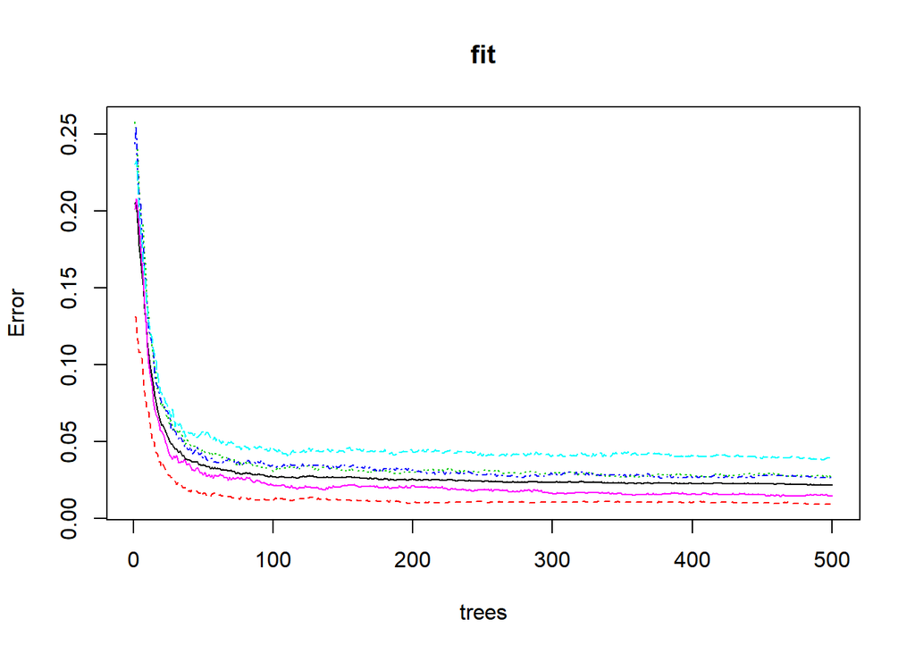

```r
fit <- randomForest(training_columns$classe ~ .,data = training_preprocess, do.trace=F)
plot(fit)
```

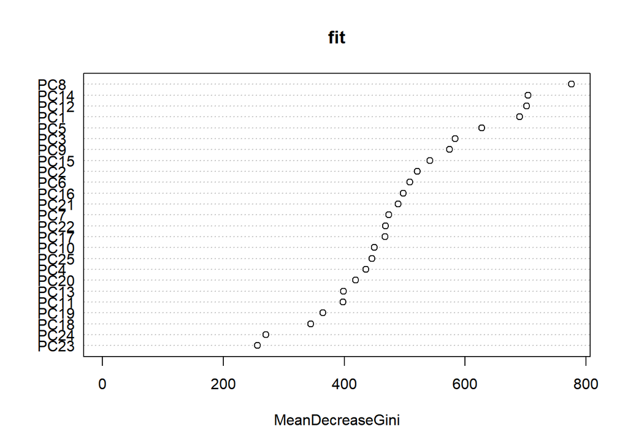

```r
varImpPlot(fit)
```

### MODEL VALIDATION

##### Applying for the testing set and predict for quiz data

```r
testing_columns <- testing[,-col_names]
testing_columns[testing_columns==""] <- NA
NArate <- apply(testing_columns, 2, function(x) sum(is.na(x)))/nrow(testing_columns)
testing_columns <- testing_columns[!(NArate>0.95)]
confusionMatrix(testing_columns$classe,predict(fit,predict(pre_process,testing_columns[,1:52])))
```

```
## Confusion Matrix and Statistics
##
##           Reference
## Prediction    A    B    C    D    E
##          A 1110    1    3    2    0
##          B    9  739    7    0    4
##          C    0    7  675    1    1
##          D    0    1   20  621    1
##          E    0    1    0    3  717
##
## Overall Statistics
##
##                Accuracy : 0.9845
##                  95% CI : (0.9801, 0.9881)
##     No Information Rate : 0.2852
##     P-Value [Acc > NIR] : < 2.2e-16
##
##                   Kappa : 0.9803
##  Mcnemar's Test P-Value : NA
##
## Statistics by Class:
##
##                      Class: A Class: B Class: C Class: D Class: E
## Sensitivity            0.9920   0.9866   0.9574   0.9904   0.9917
## Specificity            0.9979   0.9937   0.9972   0.9933   0.9988
## Pos Pred Value         0.9946   0.9736   0.9868   0.9658   0.9945
## Neg Pred Value         0.9968   0.9968   0.9907   0.9982   0.9981
## Prevalence             0.2852   0.1909   0.1797   0.1598   0.1843
## Detection Rate         0.2829   0.1884   0.1721   0.1583   0.1828
## Detection Prevalence   0.2845   0.1935   0.1744   0.1639   0.1838
## Balanced Accuracy      0.9949   0.9902   0.9773   0.9919   0.9952
```

```r
testing_data_columns <- data_test[,-col_names]
testing_data_columns[testing_data_columns==""] <- NA
NArate <- apply(testing_data_columns, 2, function(x) sum(is.na(x)))/nrow(testing_data_columns)
testing_data_columns <- testing_data_columns[!(NArate>0.95)]
testdataPC <- predict(pre_process,testing_data_columns[,1:52])
testing_data_columns$classe <- predict(fit,testdataPC)
testing_data_columns$classe
```

```
##  [1] B A A A A E D B A A A C B A E E A B B B
## Levels: A B C D E
```